# Theory of Computation Final Study Guide

### Equivalence with Context-Free Grammars

- Theorem: A language is context free iff some pushdown automaton recognizes it
  - As usual with iff statements, you have to prove both sides of the statement
- Theorem Part 1: If a language is context free, then some pushdown automaton recognizes it
  - Proof: Let $Q$ and $r$ be states of the PDA and let $a$ be in $\Sigma_{\lambda}$ and $s$ be in $\Gamma_{\lambda}$
    - Say that we want the PDA to go from $q$ to $r$ when it reads $a$ and pops $s$
      - We want to push the entire string $u = u_1...u_l$ on the stack at the same time
      - We can implement this action by introducing new states $q_1..q_{l-1}$ and setting the transition function as:

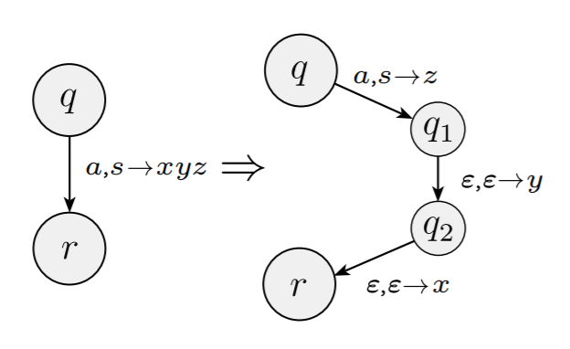

      - From this implementation, we can come up with the state diagram that completes the proof

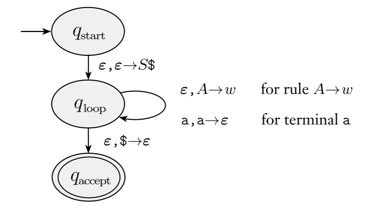

- Theorem Part 2: If a pushdown automaton recognizes some language, then it is context free
  - Proof: Say that $P = (Q, \Sigma, \Gamma, \delta, q_o, \{q_{accept}\})$ and construct $G$. The variables of $G$ are $\{A_{pq} | p, q \in Q\}$. The start variable is $A_{q_o, q_{accept}}$. Now we want to describe $G's$ rules in three parts:
    - For each $p, q, r, s \in Q, u \in \Gamma$, and $a, b \in \Sigma_{\lambda}$ if $\delta(p, a, \lambda)$ contains $(r, u)$ and $\delta(s, b, u)$ contains $(q, e)$, put the rule $A_{pq} \to aA_{rs}b$ in $G$
    - For each $p, q, r \in Q$, put the rule $A_{pq} \to A_{pr}A_{rq}$ in $G$
    - For each $p \in Q$, put the rule $A_{pp} \to \lambda$ in $G$
    - The following images may help with the understanding

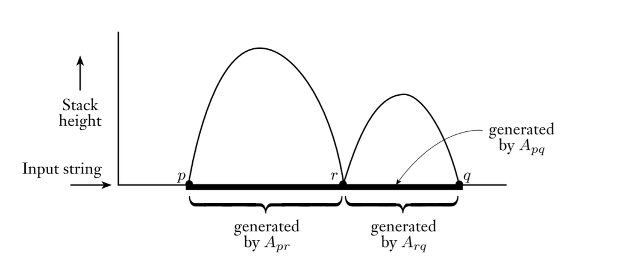

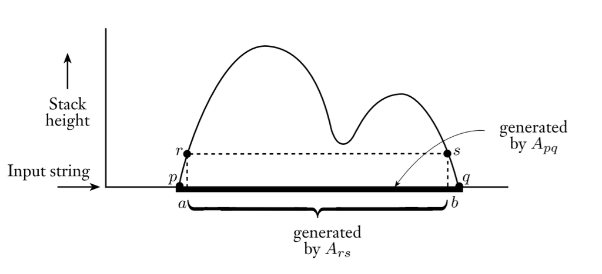

### Pumping Lemma for Context Free Languages

- The **pumping lemma** states that every context free language has a special value called the **pumping length** such that all longer strings in the language can be pumped
  - Being pumped is a little different in this sense; it means that the string can be divided into five parts (rather than three) so that the second and fourth parts may be repeated together any number of times such that the resulting string is still in the language
- Theorem: Pumping Lemma
  - If $A$ is a context free language, then there is a number $p$ (the pumping length) where, if any string $s$ is in $A$ with length at least $p$, then $s$ may be divided into five pieces: $s=uv^ixy^iz$ such that $s$ satisfies the following conditions:
    - for each $i \geq 0, uv^ixy^iz \in A$
    - $|vy| > 0$
    - $|vxy| \leq p$
- Proof: Pumping Lemma
  - Let $G$ be a CFG for CFL $A$
  - Let $b$ be the maximum number of symbols in the right-hand side of a rule (assume at least 2)
    - In any parse tree using this grammar, we know that:
      - The height of the parse tree is at most $h$ where $h$ is the number of steps between the start variable and the leaf nodes
      - The length of the string generated is at most $b^h$
  - Say that $|V|$ is the number of variables in $G$
    - We set $p$ to be at least $b^{|V| + 1}$
    - If $s \in A$ and $|s| \geq p$, the parse tree must be at least $|V| + 1$ high
      - This is because $b^{|V| + 1} \geq b^{|V|} + 1$
  - To see how to pump any string $s$ that meets the above requirements, let $\tau$ be one of its parse trees
    - If $s$ has several parse trees, choose $\tau$ to be a parse three with the smallest number of nodes
    - We know that $\tau$ must be at least $|V| + 1$ high
      - This means the longest path from the root to a leaf is at least $|V| + 1$
    - Because $G$ only has $|V|$ variables, we know that there will be some variable $R$ that will appear more than once on that path
  - Divide $s$ into $uvxyz$ as stated above
    - Each recurrence of $R$ has a larger subtree that generates $xvy$ and the lower occurrence generates just $x$ with a smaller subtree
      - Both of these subtrees are generated by the same variable so we can make substitutions and still have a valid parse tree
        - Replacing the smaller tree by the larger tree gives parse trees for the string $uv^ixy^iz$ at each $i > 1$
        - Replacing the larger tree by the smaller tree gives parse trees for the string $uxz$
      - This establishes the proof for the first condition of the lemma
  - For the second condition, we need to ensure that $v$ and $y$ are not both $\lambda$
    - If they were to both be $\lambda$, the parse tree obtained by substituting the smaller tree for the larger tree would have fewer nodes than $\tau$ does and it would still generate $s$
      - This isn’t possible because we had already chosen $\tau$ to be a parse tree for $s$ with the smallest possible number of nodes; that is why we chose $\tau$ to be that way
  - For the third condition, we need to make sure that $vxy$ isn’t any larger than $p$
    - In the parse tree for $s$, the upper occurrence of $R$ generates $vxy$
    - We also chose $R$ so that both occurrences fall within the bottom of $|V| + 1$ variables on the path and we chose the longest path in the parse tree
      - This means that the subtree where $R$ generates $vxy$ is at most $|V| + 1$ high
      - A tree of this height can generate a string of length, at most, $b^{|V| + 1 } = p$

# Turing Machines

- Turing machines are similar to a finite automaton but have unlimited and unrestricted memory
- Much more accurate model of a general purpose computer
- Can do everything that a real computer can do
- Uses an infinite tape as its unlimited memory; has a tape head that can read and write symbols and move around the tape
  - Initially the tape contains only the input string and is blank everywhere else
  - If the machine eneds to store information, it may write it on the tape
  - To read information it has written, the machine can move its head back over the tape
  - Continues computing until it decides to produce an output
    - The output is either **accept** or **reject** and is obtained by entering designated accepting or rejecting states
    - If it never reaches an accepting or rejecting state, it will continue forever and never halt
  - The schematic of a turing machine is:

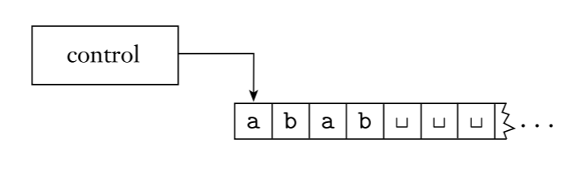

    - The $\sqcup$ are blank spaces that the turing machine can write on
- Summary of differences between finite automata and turing machines:
  - Turing machines can both read and write on a tape
  - The read-write head can move both to the left and right
  - The tape is infinite
  - The special states for accepting and rejecting take place immediately
- Example: $L = \{w\#w | w \in \{0, 1\}^*\}$
  - We want to make a turing machine, call it $M$, that accepts input if it is a member of $L$, otherwise reject it
  - $M$ = “On input string $w$:
    - Zig-zag across the tape to the corresponding positions on either side of the $\#$ symbol and check whether these positions contain the same symbol. If they do not, or if no $\#$ is found, **reject**. Cross off symbols as they are checked to keep track of which symbols correspond
    - When all symbols to the left of the $\#$ have been crossed off, check for any remaining symbols on the right of the $\#$. If any symbols remain, **reject**. Otherwise, **accept**"
  - The following picture demonstrates the process for $M's$ tape after reading input $011000\#011000$

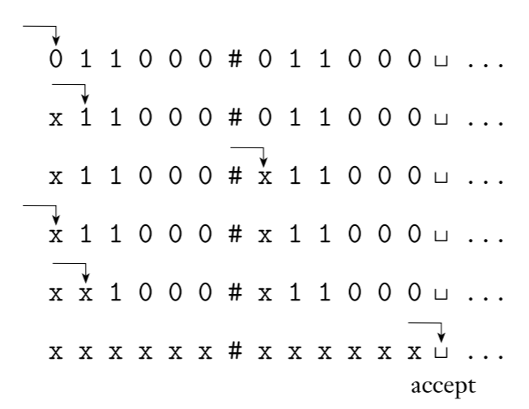

- Formal Definition:
  - A **turing machine** is a 7-tuple, $(Q, \Sigma, \Gamma, \delta, q_o, q_{accept}, q_{reject})$, where $Q, \Sigma, \Gamma$ are all finite sets and:
    - $Q$ is the set of states
    - $\Sigma$ is the input alphabet that does **not** contain the **blank symbol** $\sqcup$
    - $\Gamma$ is the tape alphabet, where $\sqcup \in \Gamma$ and $\Sigma \subseteq \Gamma$
    - $\delta: Q \times \Gamma \to Q \times \Gamma \times \{L, R\}$ is the transition function
    - $q_o \in Q$ is the start state
    - $q_{accept} \in Q$ is the accept state
    - $q_{reject} \in Q$ is the reject state, where $q_{reject} \neq q_{accept}$
- The **configuration** of a turing machine is a setting of the computation, changes in the current state, and the current tape contents
- Configurations are represented as $uqv$ for a state $q$ and two strings $u$ and $v$ over the tape alphabet $\Gamma$
  - The current state is $q$, the current tape contents is $uv$, and the current head location is the first symbol of $v$
    - The tape contains blank symbols following the last symbol of $v$
  - For example: $1011q_701111$ represents the configuration when the tape is $101101111$
    - The current state is $q_7$ and the head is currently on the second $0$. The below figure represents this configuration

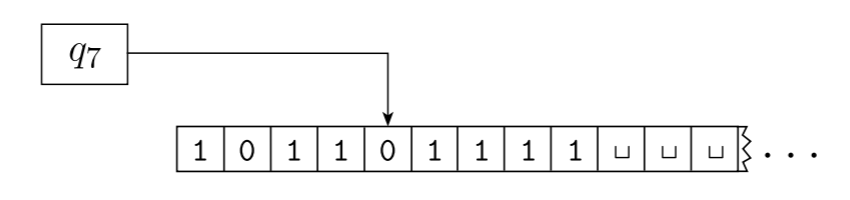

### Recognizable

- We call a language **turing-recognizable** if some turing machine recognizes it
- Three outcomes are possible from a turing machine: accept, reject, or loop
  - By loop, it is meant that the machine does not halt (it never reaches an accept or reject state)
- A machine can fail to accept an input by entering the $q_{reject}$ state or by looping
  - It can be difficult to determine if a machine is looping or if it is just taking a long time, so it is preferable to have a machine halt on all inputs
    - This means they would never loop
  - Machines that halt one very input are called **deciders** because they make a decision for every input; these machines are also said to **decide** that language

### Decidable

- We call a language **turing-decidable** (or simply **decidable**) if some turing machine decides it
- Any language that is decidable is also recognizable, but not vice versa
- Example:
  - Describe a turing machine $M$ that decides $L = \{O^{2^n} | n \geq 0\}$, aka the language consiting of all strings of $0's$ whose length is a power of $2$
    - $M$ = “On input string $w$:
      - Sweep left to right across the tape, crossing off every other 0
      - If in stage 1 and the tape contained a single $0$, accept
      - If in stage 1 and the tape contained more than a single $0$ and the number of $0's$ was odd, reject
      - Return the head to the left-hand end of the tape
      - Go to stage 1"
    - Each iteration of stage 1 cuts the number of $0's$ in half
    - As the machine sweeps across the tape in stage 1, it keeps track of the number of $0's$ seen is even or odd
      - If the number is both odd and greater than $1$, it rejects
      - If the number is $1$, it accepts
    - Formal definition of $M = (Q, \Sigma, \Gamma, \delta, q_1, q_{accept}, q_{reject})$:
      - $Q = \{q_1, q_2, q_3, q_4, q_5, q_{accept}, q_{reject}\}$
      - $\Sigma = \{0\}$
      - $\Gamma = \{0, x, \sqcup\}$
      - $\delta$ is described with the state diagram below
      - $q_1$ is the start state, $q_{accept}$ is the accept state, $q_{reject}$ is the reject state

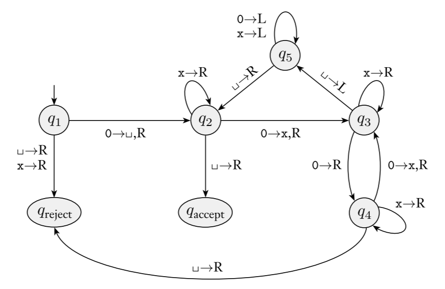

    - The following image is a series of configurations of $M$ when ran on input $0000$

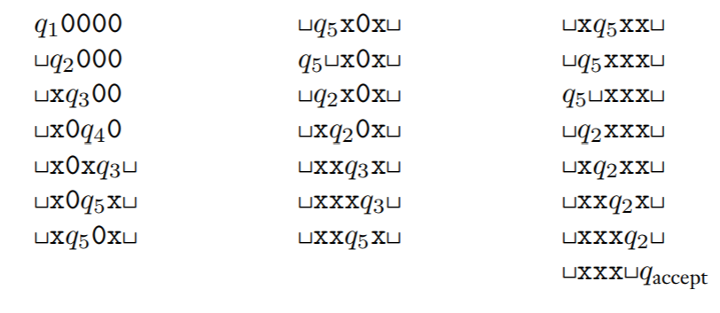

### Multitape Turing Machines

- A **multitape turing machine** is like an ordinary turing machine with more than one tape
  - Each tape has its own head for reading and writing
  - Initially the input is on tape 1 and the others are blank; the transition function is changed to allow for reading, writing, and moving the heads on some or all of the tapes. The formal definition of the transition function is:

  $$\delta: Q \times \Gamma^k \to Q \Gamma^k \times \{L, R, S\}^k$$
  - k is the number of tapes. The expression below means that if the machine is in state $q_i$ and the heads $1$ through $k$ are reading symbols $a_1$ through $a_k$, the machine goes to state $q_j$, writes symbols $b_1$ through $b_k$, and directs each head to move left, right, or stay put as specified:

  $$\delta(q_i, a_1, ..., a_k) = (q_j, b_1, ..., b_k, L, R, ..., L)$$
- Even though it may seem that multitape machines are more powerful than single tap machines, they have the same amount of power
- Theorem: Every multitape turing machine has an equivalent single-tape turing machine
- Proof: Show how to convert a multitape turing machine $M$ to an equivalent single-tape turing machine $S$. We need to show how to simulate $M$ with $S$
  - Say that $M$ has $k$ tapes- then $S$ simulates the effect of $k$ tapes by storing their information on its single tape
    - It uses the new symbol $\#$ as a delimiter to separate the contents of the different tapes
  - S must also keep track of the head locations for the multiple tapes
    - This is achieved by writing a tape symbol with a dot above it to mark the place where the head would be
  - The following figure demonstrates how this is done:

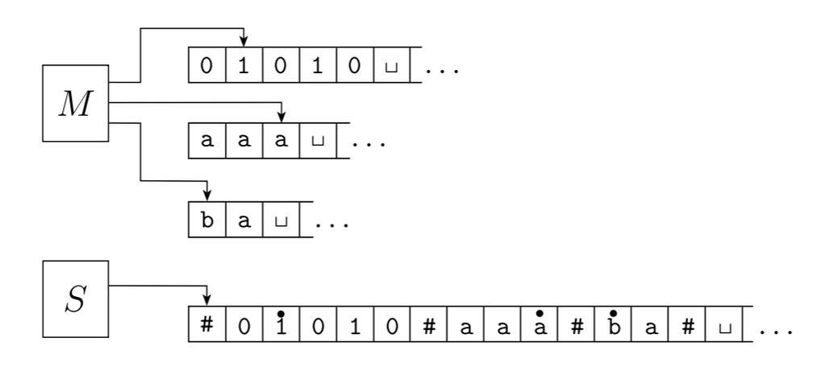

- Example:
  - $S$ = “On input $w = w_1...w_n$
    - First $S$ puts its tape into the format that represents all $k$ tapes of $M$. The formatted tape contains:

    $$\#\dot{w_1}w_2 \dotsm w_n\#\dot{\sqcup}\#\dot{\sqcup}\# \dotsm \#$$
    - To simulate a move:
      - $S$ scans its tape from the first $\#$ which marks the left-hand end
      - It continues to scan until the $(k+1)^{st}$ $\#$ which marks the right-hand end
        - This determines the symbols under the heads
      - $S$ makes a second pass to update the tapes according to the way that $M$ dictates
    - If $S$ moves one of the heads right onto a $\#$, it means that $M$ has moved the corresponding head onto the blank portion of the tape, so $S$ writes a blank symbol on this tape cell and shifts the contents one unit to the right, then continues as before"

### Nondeterministic Turing Machines

- At any point in a computation, the machine may proceed according to several possibilities (similar to nondeterministic finite automata)
- The transition function is: $\delta: Q \times \Gamma \to P(Q \times \Gamma \times \{L, R\})$
- As a refresh on what it means to be nondeterministic:
  - A **nondeterministic** machine has several choices for the next state at any given point
  - The machine will split into multiple copies of itself and follow **all** possibilities at the same time, in parallel
  - If there is nowhere for the input to go, that branch of the machine dies
  - If any branch of the machine is accepted, the machine accepts the input

### Enumerators

- An **enumerator** if a turing machine with an attached printer which can be used as an output device to print strings
- Any time the turing machine wants to add a string to the list, it sends the string to the printer. The schematic is:

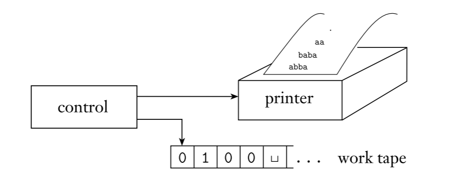

- An enumerator starts with a blank input
  - If it doesn’t halt, it may print an infinite list of strings
  - The language enumerated is a collection of all of the strings that it eventually outputs
  - It may generate the strings of the language in any order and it may have repititions
- Theorem: A language is turing recognizable iff some enumerator enumerates it
- Proof:
  - First, show that we have an enumerator $E$ that enumerates a language $A$. There is a turing machine $M$ recognizes $A$. $M$ works in the following way:
    - $M$ = “On input $w$:
      - Run $E$. Every time that $E$ outputs a string, compare it to $w$
      - If $w$ ever appears in the output of $E$, **accept**"
    - $M$ accepts those strings that appear on $E's$ list
  - Look at the other direction of the iff. If a turing machine $M$ recognizes a language $A$, we can construct the enumerator $E$ for $A$. Say that $s_1, s_2, s_3, ...$ is a list of all of the possible strings in $\Sigma^*$
    - $E$ = “Ignore the input
      - Repeat the following process for $i \in \mathbb{N}$:
        - Run $M$ for $i$ steps on each input $s_1, s_2, s_3, …, s_i
        - If any computations accept, print out the corresponding $s_j$"
    - If $M$ accepts a particular string $s$, eventually it will appear on the list that $E$ outputs; it will actually appear infinitely many times because $M$ runs from the beginning on each string for each repitition of step 1. It gives the effect of $M$ running in parallel on all possible input strings

### Equivalence with Other Models

- Each variance of the turing machine has equal power
- All models that feature unlimited memory end up being equivalent in power as long as they satisfy reasonable requirements
  - An analogy: Is there an algorithm that can be programmed in one language but not another?
    - No, all reasonable programming languages have the power to create the same algorithms (they’re just not always created the exact same way)
    - You could say that languages describe **exactly** the same class of algorithms
  - This analogy holds for computational models as well
    - Any two computational models that satisfy certain reasonable requirements can simulate one another and therefore are equivalent in power
- Important corollary: Even though we can imagine different types of computational models, the class of algorithms that they describe remains the same

### Definition of an Algorithm

- An **algorithm** is a collection of simple instructions where the purpose is to carry out some task
  - Sometimes they are called procedures or recipes in everyday life
  - They are also important in mathematics
- Hilbert’s Problem
  - A set of 23 mathematical problems that were posed as a challenge for the coming century in 1900.
  - The $10^{th}$ problem on the list was about algorithms
    - Devise an algorithm that tests whether a polynomial has an integer root
    - He assumed that this was possible- all that had to be done was someone being able to construct the method
      - Plot twist: he was wrong. There isn’t an algorithm that can do this
      - Mathematitions at that time wouldn’t have been able to prove that it is impossible because they didn’t even have the definition of an algorithm
    - Fast forward to 1936- the Church Turing thesis. They defined an algorithm
      - Church did it with $\lambda$-calculus and Turing did it with his machines and the definitions were shown to be equivalent
    - Fast forward again to 1970- Yuri Matijasevic built on the work of Martin Davis, Hilary Putnam, and Julia Robinson to show that there wasn’t an algorithm to determine whether a polynomial has integral roots
  - Rephrase Hilbert’s tenth problem in our own terminology

  $$D = \{p~ | ~p \text{ is a polynomial with an integral root}\}$$
  - The problem essentially asks: is $D$ decidable? No, it’s not. However, we can show that it is recognizable
    - Also, if $D$ was univariate it would be decidable

# Decidability

- Decidability and Regular Languages
  - With regular languages, we give algorithms for testing if a finite automaton accepts a string, if a language of a finite automaton is empty, and if two finite automata are equivalent
  - The **acceptance problem**
    - The acceptance problem for DFAs tests whether or not a particular DFA accepts a given string
    - This problem can be expressed as a language, $A_{DFA}$
      - The language has all of the encodings of all DFAs together with strings that the DFAs accept
        $$A_{DFA} = \{\langle B, w \rangle | B \text{ is a DFA that accepts input string } w\}$$
    - Theorem: $A_{DFA}$ is a decidable language
      - Proof idea: We need to present a turing machine $M$ that decides $A_{DFA}$:
        - $M$ = “On input $\langle B, w \rangle$, where $B$ is a DFA and $w$ is a string:
          - Simulate $B$ on input $w$
          - If the simulation ends in an accept state, accept. If it ends in a non-accepting state, reject"
    - Theorem: $A_{NFA}$ is a decidable language
      - Proof idea: We need to present a turing machine $N$ that decides $A_{NFA}$
        - $N$ = “On input $\langle B, w \rangle$, where $B$ is an NFA and $w$ is a string:
          - Convert NFA $B$ to an equivalent DFA $C$
          - Run the turing machine $M$ from the above theorem on input $\langle C, w \rangle$
          - If $M$ accepts, accept. Otherwise, reject"
    - Theorem: $A_{REX}$ is a decidable language
      - Proof idea: We need to present a turing machine $P$ that decides $A_{REX}$
        - $P$ = “On input $\langle R, w \rangle$ where $R$ is a regular expression and $w$ is a string:
          - Convert $R$ into an equivalent NFA $A$
          - Run the turing machine $N$ from the above theorem on input $\langle A, w \rangle$
          - If $N$ accepts, accept. If $N$ rejects, reject"
  - **Emptiness Testing**: $E_{DFA} = \{\langle A \rangle | A \text{ is a DFA and } L(A) = \varnothing\}$
    - Theorem: $E_{DFA}$ is a decidable language
      - Proof Idea: You need to design some turing machine $T$ that does shit, idk
        - $T$ = “On input $\langle A \rangle$ where $A$ is a DFA:
          - Mark the start state of $A$
          - Repeat until no new states get marked
            - Mark any state that has a transition coming into it from any state that is already marked
          - If no accept state is marked, accept. Otherwise, reject"
    - Let $EQ_{DFA} = \{\langle A, B \rangle | A \text{ and } B \text{ are DFAs and } L(A) = L(B)\}$
    - Theorem: $EQ_{DFA}$ is a decidable language
      - Proof Idea: Create a DFA $C$ from $A$ and $B$ where $C$ accepts strings that are accepted by either $A$ or $B$ but not both
        - $F$ = “On input $\langle A, B\rangle$ where $A$ and $B$ are DFAs:
          - Construct a DFA $C$ as described
          - Run turing machine $T$ from the above proof on input $\langle C\rangle$
          - If $T$ accepts, acccept. If $T$ rejects, reject"

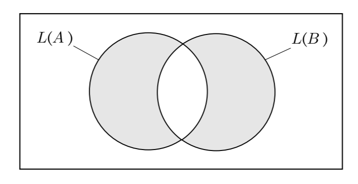

- Decidability and Context Free Languages
  - **Acceptance Problem** : $A_{CFG} = \{\langle G, w \rangle | G \text{ is a CFG that generates string } w\}$
    - Theorem: $A_{CFG}$ is a decidable language
      - Proof idea: Convert $G$ into Chomsky Normal Form by creating a turing machine $S$ for $A_{CFG}$ as follows:
        - $S$ = “On input $\langle G, w \rangle$ where $G$ is a CFG and $w$ is a string:
          - Convert $G$ to an equivalent grammar in Chomsky normal form"
          - List all derivations with $2n - 1$ steps where $n$ is the length of $w$
            - Unless $n = 0$, then list all derivations with one step
          - If any of these derivations generate $w$, accept. Otherwise, reject
  - **Emptiness Testing**: $E_{CFG} = \{\langle G \rangle | G \text{ is a CFG and } L(G) = \varnothing\}$
    - Theorem: $E_{CFG}$ is a decidable language
      - Proof Idea: Create turing machine $R$ that marks all of the terminal symbols in the grammar, scans for all of the rules in the grammar, and marks any variables in rules of which there is a variable that can be replaced by some string of symbols
        - $R$ = “On input $\langle G\rangle$ where $G$ is a CFG:
          - Mark all terminal symbols in $G$
          - Repeat until no new variables get marked:
            - Mark any variable $A$ where $G$ has a rul $A \to U_1U_2 \dotsm U_K$ and each symbol $U_1, ..., U_k$ has already been marked
          - If the start variable is not marked, accept. Otherwise, reject"
    - Let $EQ_{CFG} = \{\langle G, H \rangle | G \text{ and } H \text{ are CFGs and } L(G) = L(H)\}$
    - Theorem: Every context-free language is decidable
      - Proof Idea: Use the turing machine $S$ from a couple theorems ago. Let $G$ be a CFG for $A$ and design a turing machine $M_G$ that decides $A$
        - $M_G$ = “On input $w$:
          - Run $S$ on input $\langle G, w\rangle$
          - If $S$ accepts, accept. If it rejects, reject"

### Undecidability

- Set Theory Notations and Definitions:
  - Given two sets $A$ and $B$ and a function $f$ from $A$ to $B$
    - We say that $f$ is **one to one** (or injective) if it never maps two different elements to the same place
      - i.e. $f(a) \neq f(b)$ when $a \neq b$
      - Two unique $x$ values will never have the same $y$ values
    - We say that $f$ is **onto** (or surjective) if it hits every element of $B$
      - i.e. for every $b \in B$ there is an $a \in A$ such that $f(a) = b$
    - We say that $f$ is **bijective** if it is both one to one and onto
  - We say that a set $A$ is **countable** if it is either finite or has the same cardinality as $\mathbb{N}$
  - Theorem: $\mathbb{R}$ is the set of real numbers, show that $\mathbb{R}$ is uncountable
    - Proof: We need to show that there is no existing correspondence between $\mathbb{N}$ and $\mathbb{R}$ which will be a proof by contradiction; show that $f$ fails to work as it should
      - We need to create an $x$ so that each digit makes $x$ different from one of the real numbers that is paired with an element of $\mathbb{N}$
      - Example: Suppose that the correspondence $f$ exists
        - Let $f(1) = 3.14159..., f(2) = 55.55555...., f(3) = ....,$ and so on
        - The following table shows the hypothetical correspondence $f$ between $\mathbb{N}$ and $\mathbb{R}$

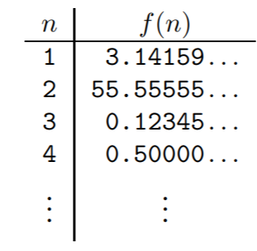

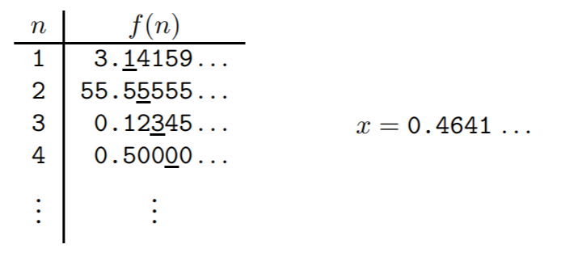